# Sherlock Night

Anna Golovchenko and Ildar Belyalov

03 February, 2017

[figure not shown]

I prefer to text

## Данные

Данные были извлечены из Твиттера. Мы начали собирать все твиты с хештегом #НочьШерлока, которые держался на первом месте топа по России в дни премьер, 16го января и дошли до 3х часов ночи 3го числа, после чего Твиттер перестал отдавать данные. Политика соцсети такова, что из нее можно вытащить данные не старше двух недель. Поэтому, к сожалению, шумиха вокруг первой серии не попала в нашу базу.

**Период:** с 3 по 16 января

**Твитов:** 376 056 с хештегом *#ночьшерлока*

**Авторов:** 43 576

**Средняя длина твита:** 6-7 слов

На графике изображено распределение твитов по дням. **Первый пик** - показ второй серии, в это время частота твитов с хештегом достигает 75 тыс. в час. **Маленький бугорочек** рядом с 16 числом - день, когда слили третью серию. Слив заметно повлиял на активность фандома на следующий за ним день премьеры на первом канале. Частота твитов с хештегом во время показа на первом достигает лишь 45 тыс.

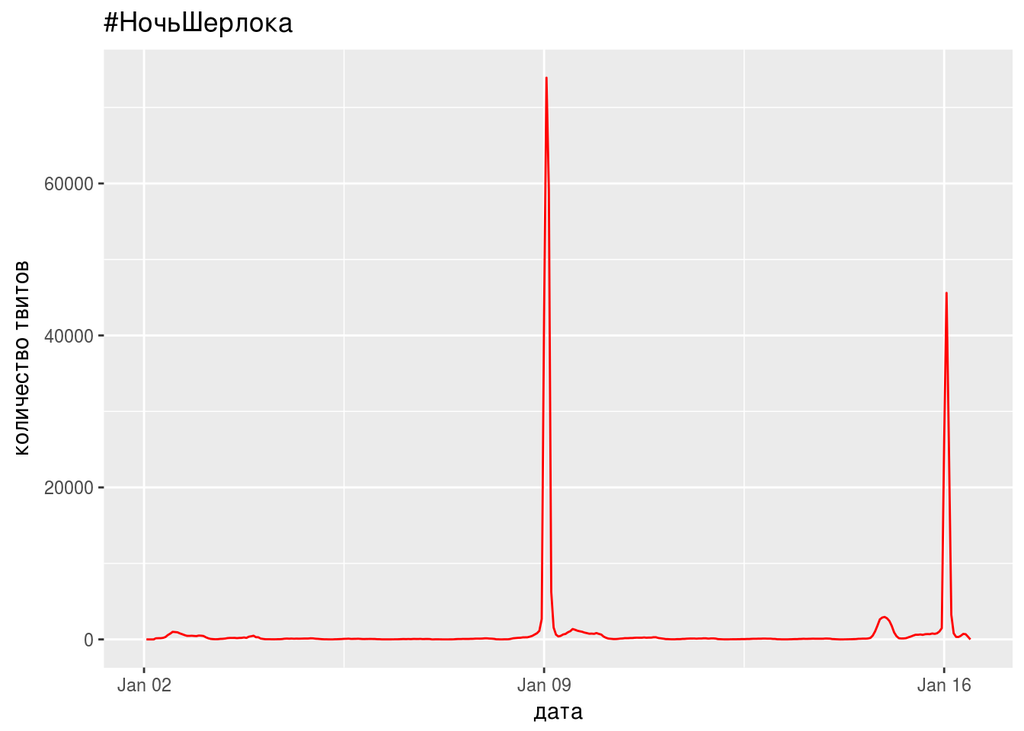